# Manuscritos reproducibles con Quarto

Elena Quintero

2026-05-06

## A typical research workflow

[figure not shown]

1. Prepare data (**spreadsheet**)
2. Analyse data (**R**)
3. Write report/paper (**Word**)

## A typical research workflow

However, this workflow can unchain a maelstrom of email attachments …

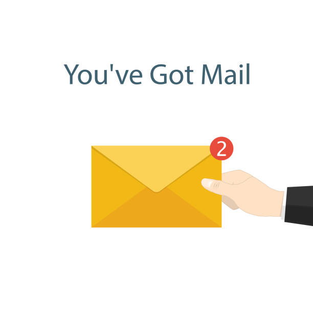

## Problems of a broken workflow

- How did you get these values? What analysis is behind this figure? Did you account for …?
- What dataset was used? Which individuals were left out? Where is the clean dataset?
- Oops, there is an error in the data. Can you repeat the analysis? And update figures/tables in Word!

## Copy-pasting can be tedious & problematic

[figure not shown]

*The majority of replication problems emerge because authors either modified their code but failed to update their manuscript or made an error while transcribing their results into their paper* - [Eubank 2006](https://www.cambridge.org/core/journals/ps-political-science-and-politics/article/lessons-from-a-decade-of-replications-at-the-quarterly-journal-of-political-science/284B2830BFD99888B42D4CEABC28B9EE)

## Reproducibility problems

You can find difficulties when resuming your own work and you can **struggle to reproduce** your own results from a few weeks/months/years ago…

Also, revising non-reproducible manuscripts can be very messy

## Doing dynamic reports in R

[figure not shown]

[figure not shown]

## Quarto

[figure not shown]

## Quarto

Quarto connects code with results

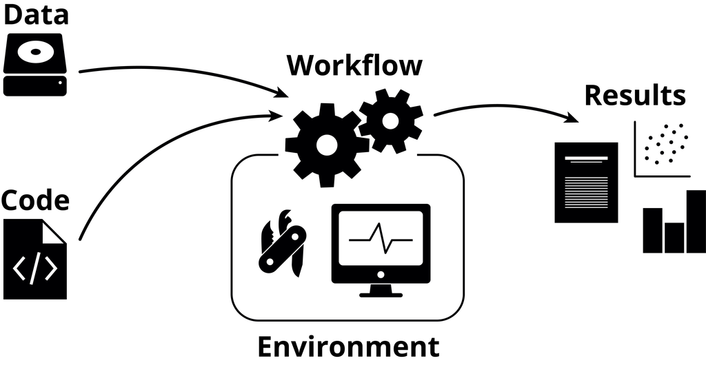

## Quarto vs. R Markdown

- Quarto is a command line tool
- Quarto ≈ R Markdown 2.0
- Quarto is language-agnostic (does not depend on R)
- Quarto has all functionality built-in (you don’t need to install another package to create e.g. presentations)
- The Quarto format is similar to R
- Markdown Quarto can render R Markdown documents
- R Markdown will continue to be supported, but Quarto is the focus of new functionality and major development

## Quarto

Quarto connects code with results

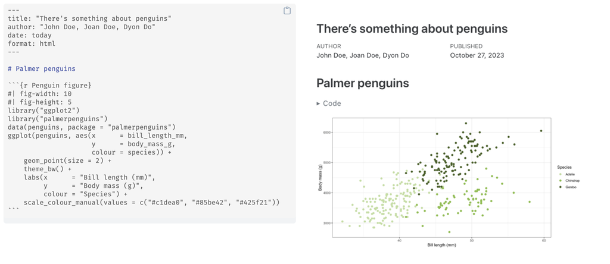

## Quarto structure

[figure not shown]

## Quarto structure

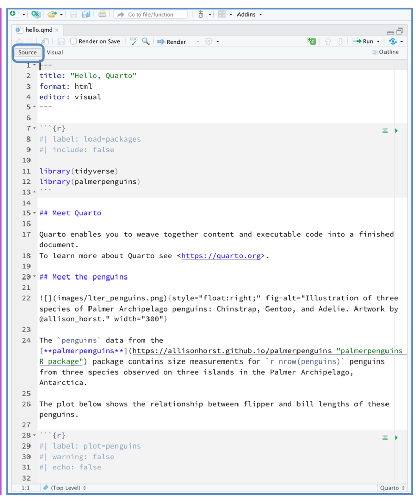

**A YAML header:** Defines document-wide options. Specifies the output format. Can include several parameters.

**Markdown text:** Freely add and format text using markdown.

**Code chunks:** Evaluate code and show its output. Specify global and/or local chunk options (e.g. figure dimensions). Also works with other languages (e.g. Python).

## Quarto documents are…

- **Fully reproducible** (trace all results including tables and plots)
- **Dynamic** (can be regenerated with 1 click)
- **Multiple outputs**:
  - documents
  - presentations
  - books
  - websites…

## Chunks

Chunks can execute code from different languages

````markdown
```{r}
plot(iris)
```
````

Not only R, but also:

- Python
- Julia
- C++
- SQL
- Bash
- Rcpp
- Stan
- JavaScript
- CSS

…etc

## Code chunk options (Execution Options)

Chunk options are embbeded with `#|`

````markdown
```{r}
#| echo: FALSE
#| eval: TRUE
#| fig-cap: "My figure caption"
plot(iris)
```
````

[Quarto Execution Options](https://quarto.org/docs/computations/execution-options.html#raw-output)

## Naming chunks

````markdown
```{r}
#| label: iris-plot1
#| echo: FALSE
#| eval: TRUE
#| fig-cap: "My figure caption"
plot(iris)
```
````

## Naming chunks

Can help debugging and navigating long docs

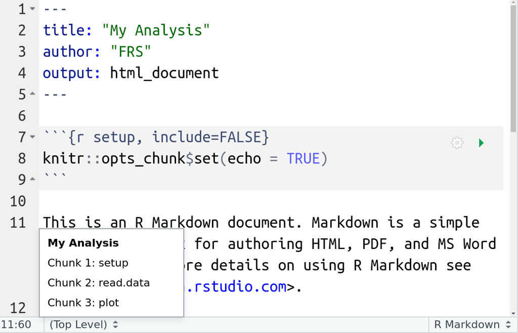

## Text formatting

Markdown syntaxis

`# Header`

`## Subheader`

`*italic*`

`**bold**`

`[a link](https://example.com)`

Can use [Visual Markdown Editor](https://rstudio.github.io/visual-markdown-editing/)

## Render

With just one click (`Render`):

[figure not shown]

## Output formats

- **Reports** and general documents (HTML, PDF, Jupyter Notebook, Microsoft Word)
- **Presentations** (reveal.js, PowerPoint, Beamer)
- **Interactive documents** (Observable, R Shiny)
- **Books**, **blogs** and **websites** (the course website is done with Quarto)
- **Journal articles**
- Your own **custom formats**

# Let’s try

## Writing a quarto document

- Try visual editor
- Parameterised reports
- Add bibliography